# Assignment 4

# Data Structures and Algorithms - EE4371

```
                                                                                           Nohan Joemon
                                                                                           CH19B072
```

## Q1: Show how to implement a stack using two queues. Analyze the running time of the stack operations.

## Answer:

### Explanation:

GIVEN: Two queues Q1 and Q2 along with their standard operations - enqueue and dequeue and other methods like is_empty(),getfront(),len(),etc.

OBJECTIVE: To implement a stack S using Q1 and Q2 - having standard stack operations - push and pop and other methods like is_empty(),top(),len(),etc

EXPLANATION: As the first step, label one queue as active and the other one as inactive (Lets assume Q1 as active and Q2 as inactive initially). All of our data will be stored in active queue. Inactive queue will come into picture only during pop operation

```
   LEN:
```

s.len() is length of active queue, which is active.size

```
   IS_EMPTY:
```

s.is_empty() checks if length of active queue is 0

```
   TOP:
```

s.top() is last non-empty element in active queue, which is the element at position (active.front + active.size -1 ) % len(active.data)

```
   PUSH:
```

For s.push(e), we should enqueue the element e onto the active queue

```
   POP:
```

For s.pop(), we should dequeue all elements - except the last element - from the active Queue,and simultaneously enqueue them into the inactive Queue. Now, reverse the roles of both queues (active becomes inactive and inactive becomes active). Now, dequeue the only element in the (now) inactive queue

```python
# IMPLEMENTATION IN PYTHON

# === Standard implementation of Queue (provided for reference) ===

class Queue:
    default_capacity = 10
    def __init__(self):
        self.data = [None]*Queue.default_capacity
        self.size = 0
        self.front = 0
    def len(self):
        return self.size
    def is_empty(self):
        return self.size == 0
    def getfront(self):
        if self.is_empty( ):
            raise Empty("Queue is empty")
        return self.data[self.front]
    def dequeue(self):
        if self.is_empty( ):
            raise Empty("Queue is empty")
        answer = self.data[self. front]
        self.data[self.front] = None
        self.front = (self.front + 1) % len(self.data)
        self.size = self.size-1
        return answer
    def enqueue(self, e):
        if self.size == len(self.data):
            self.resize(2*len(self.data))
        avail = (self.front + self.size) % len(self.data)
        self.data[avail] = e
        self.size += 1
    def resize(self, cap):
        old = self. data
        self. data = [None]*cap
        walk = self. front
        for k in range(self. size):
            self. data[k] = old[walk]
        walk = (1 + walk) % len(old)
        self. front = 0




# ===== Implementation of Stack using two queues Q1 and Q2 =========

class Stack_using_two_queues:
    def __init__(self):
        Q1=Queue()
        Q2=Queue()
        self.active = Q1
        self.inactive = Q2
    def len(self):
        return self.active.size
    def is_empty(self):
        return self.active.size==0
    def top(self):
        if self.is_empty():
            raise Exception("Stack is empty")
        return self.active.data[(self.active.front+self.active.size-1)% len(self.active.data)]
    def push(self,e):
        return self.active.enqueue(e)
    def pop(self):
        if self.is_empty():
            raise Exception("Stack is empty")
        for i in range(self.active.size-1):
            self.inactive.enqueue(self.active.dequeue())
        self.active,self.inactive = self.inactive,self.active
        return self.inactive.dequeue()


# ======== Testing =====
s=Stack_using_two_queues()
s.push(23)
s.push(34)
s.push(100)
print(s.len())
print(s.top())
print(s.pop())
print(s.pop())
print(s.is_empty())
```

```
3
100
100
34
False
```

### RUNNING TIME OF PUSH AND POP

#### Push:

Running time of push is same as running time of enqueue operation of active queue. From the reference queue class provided, it is clear that no loops are involved, and only O(1) operations are involved in enqueue operation. Hence, running time of push is O(1)

#### Pop:

For pop operation, we have a loop that runs s.len() times, and for each iteration, it performs a dequeue on active and enqueue on inactive, both of which are O(1) - this is clear from the reference queue class provided. All other steps in pop() is O(1), hence running time of pop is O(n), where n = s.len() = no of elements in Stack S

## Q2: Demonstrate what happens when we insert the keys 5, 28, 19, 15, 20, 33, 12, 17, 10 into a hash table with collisions resolved by chaining. Let the table have 9 slots, and let the hash function be h(k) = k mod 9.

## Answer:

The given Hash Table has 9 slots. Assume the slots are 0,1,2,3......8

Hash function: h(k) = kmod9 = k%9 ; where k=key

The following table (Table 1) shows the key and corresponding slots mapped through the hash function:

```
k    h(k) = k % 9

5    5
28   1
19   1
15   6
20   2
33   6
12   3
17   8
10   1
```

As seen from the above table, there is collision in slot 1 (because three keys - 28,19,10 are directed to this slot by the hash function) and in slot 6 (because two keys - 15 and 33 are directed to this slot by the hash function)

###### Resolving collisions by chaining:

In chaining, we resolve the collision by adding all keys that collide into a linked-list. Therefore, the following hash table is formed:

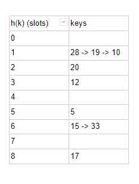

###### Observations:

1: Slots 0, 4 and 7 are unoccuppied in the hash table because the values 0, 4 and 7 were not formed by any of the keys upon mapping through hash function.

2: Slots 2,3,5 and 8 have exactly one key each. This is because those values were formed by exactly one key upon mapping through hash function

3: Slots 1 and 6 have multiple keys due to collision. We resolved collision by arranging all keys that collided in a particular slot in the form of a linked list.

###### Collision slots:

Keys are given in the order 5, 28, 19, 15, 20, 33, 12, 17, 10

Slot 1: While assigning slots, firstly 28 moves into slot 1, then 19 tries to move into the same slot- a collision occurs, and hence a linkedlist is formed: 28 -> 19. Later 10 tries to move, and the linkedlist is extended: 29 -> 19 -> 10

Slot 6: While assigning slots, first 15 moves into slot 6. Later 33 tries to move into the same slot - a collision occurs, and hence a linkedlist is formed: 15 -> 33

## Q3: Consider a binary search tree T whose keys are distinct. Show that if the right subtree of a node x in T is empty and x has a successor y , then y is the lowest ancestor of x whose left child is also an ancestor of x .

## Answer:

**Successor:** The successor of a node x in a binary search tree T is the node with the key that is the smallest key greater than x Note that successor of x( in this case, y) > x  
**Algorithm for finding successor:**

(Let the position of node x is p)

Algorithm succesor(p):

```
if right(p) is not None then {successor is leftmost position in p’s right subtree}

    walk = right(p)

    while left(walk) is not None do

        walk = left(walk)

    return walk

else {successor is nearest ancestor having p in its left subtree}
    walk = p

    ancestor = parent(walk)

    while ancestor is not None and walk == right(ancestor) do

        walk = ancestor

        ancestor = parent(walk)

    return ancestor
```

### Explanation of this question:

We solve this question in 3 steps:

##### STEP 1: Prove y is an ancestor of x

```
We know y is not equal to x (By definition of successor. Also note that elements of this tree are distinct)

Therefore, either {y is a descendant of x} or {y is an ancestor of x} or {x and y have common ancestor z}

Case 1: y is a descendant of x:
    Case 1.1 : y is in the left subtree of x:
        NOT  POSSIBLE     REASON:  Elements in left subtree of x are less than  x ; while y > x
    Case 1.2:  y is in the right subtree of x:
        NOT POSSIBLE      REASON:  In this case, x has no right subtree

Case 2: x and y have a common ancestor (let z be the first common ancestor of x and y):
     by definition of first common ancestor, x and y should be in opposite subtrees of z.
     Therefore, x > z > y or y > z > x.
     The former case is impossible because by definition of successor, y>x.
     The latter case is impossible because by definition of successor, y is the smallest key greater than x
     Therefore NOT POSSIBLE

Since Case1 and Case2 are impossible, the only remaining case, y is an ancestor of x, should be possible
```

##### STEP 2: Prove y.left is an ancestor of x:

```
As y is an ancestor of x, then either y.left should be an ancestor of x or y.right should be an ancestor of x.
If y.right is an ancestor of x, that implies x is in the right subtree of y, therefore x>y, which is impossible
Therefore, y.left is an ancestor of x
```

##### STEP 3: Prove y is the lowest ancestor of x whose left child is also an ancestor of x

```
Suppose z is this lowest ancestor. x belongs to left subtree of y (since y.left is an ancestor of x). Therefore, z also belongs to the left subtree of y (as  z is a lower ancestor of x than y).
Also, x < z since z.left is an ancestor of x
Therefore, x<z<y, which is not possible(definition of successor)
```

**Therefore, y is the lowest ancestor of x whose left child is also an ancestor of x.**

## Q4: Describe a non-recursive algorithm for enumerating all permutations of the numbers {1, 2, …,n} using an explicit stack.

## Answer:

```python
# ============== Stack class for reference ========================

class Stack():
    def __init__(self):
        self._data = []

    def __len__(self):
        return len(self._data)

    def is_empty(self):
        return len(self._data) == 0

    def push(self, value):
        self._data.append(value)

    def top(self):
        return self._data[-1]

    def pop(self):
        if self.is_empty():
            raise Empty('List is empty')
        return self._data.pop()

    def full_pop(self):
        ans = []
        while not self.is_empty():
            ans.append(self.pop())
        return ans

# ================= Function ===========================================

def find_permutations_stack(n):
    nums = {x for x in range(1, n+1, 1)} # we store the numbers 1,2,3....n in a set
    S = Stack() # S is a stack

    #Initially we store pairs: ([1],{2,3,4,...}),([2],{1,3,4,..}),([3],{1,2,4...}),..in S
    for num in nums:
        S.push(([num], nums-set([num])))


    while not S.is_empty():
        l, remaining = S.pop()   #We extract both elements in the pair as (l,remaining)
        if len(remaining) == 0:  #When all terms in remaining are transferred to l, we get a permutation ready to print
            print (l)

        else:                    #If remaining has terms in it
            for n in remaining:  #we consider one term of remaining at a time,
                                 #we transfer it from remaining to l, and push the new (l, remaining) pair into S
                l2 = l.copy()
                l2.append(n)
                S.push((l2, nums-set(l2)))


 # Testing
find_permutations_stack(3)
```

```
[3, 2, 1]
[3, 1, 2]
[2, 3, 1]
[2, 1, 3]
[1, 3, 2]
[1, 2, 3]
```

#### Explanation of code:

Take the example of {1,2,3}.

Initially we store pairs ([1],{2,3}) , ([2],{1,3}) , ([3],{1,2}) in the stack S. These pairs can be represented by pair(l, remaining)

##### while loop:

###### iter1:

S: ([1],{2,3}) , ([2],{1,3}) , ([3,1],{2}) , ([3,2],{1})

###### iter2:

last element: ([3,2],{1}). l=[3,2], remaining={1} We iterate through remaining={1}, and transfer it from remaining to l, immediately pushing it to S. Therefore, we push ([3,2,1],set()) into S.

S: ([1],{2,3}) , ([2],{1,3}) , ([3,1],{2}) , ([3,2,1],set())

###### iter3:

last element:([3,2,1],set()). l=[3,2,1], remaining=set(), remaining is empty, so we print l

S: ([1],{2,3}) , ([2],{1,3}) , ([3,1],{2})

.  
.  
.  
.  
.  
.

This process continues till S is empty

## Q5: Show that any n-node binary tree can be converted to any other n -node binary tree using O(n) rotations.

## Answer:

#### Step 1: Proving that at most n - 1 right rotations suffice to transform the tree into a right-going chain

Consider, at the extreme case that the binary tree is left-going chain initially. We need to prove that a left-going chain can be converted to a right-going chain in n-1 steps.

PROOF:

In a left-going tree, we have have 1 root + n-1 other elements. Initially, left path has length n and right path has length 1.

Each right rotation will increase the length of the right most path by at least 1 (by definition).

Therefore,after n-1 rotations, the length of the right most path becomes atleast 1 + (n-1) = n nodes long, that is, it becomes a right-going chain.

Therefore, a left going chain can be converted to a right going chain in atmost n-1 rotations

Therefore, any binary tree can be converted to a right going chain in atmost n-1 rotations

#### Step 2: Proving that atmost n-1 rotations suffice to transform a tree into a left-going chain

This is just the symmetric case of Step-1, therefore, clearly it is true

#### Step 3: Final step

Assume we have a binary tree T1 and we need to convert it into T2 in O(n) rotations.

Note that T1 and T2 have same elements, only the arrangement differs. Therefore, the corresponding right-going chain of both T1 and T2 is same (denoted by R)

T1 can be converted to R in atmost n-1 rotations (see step1) - denoted by r1,r2,r3,r4,...rk; where k <= n-1

T2 can be converted to R in atmost n-1 rotations (see step1) -denoted by s1,s2,s3,s4....sm; where m <= n-1

Therefore, R can be converted into T2 in n-1 rotations too- we just need to perform the inverse rotations of above case; ie R to T2 can done by performing sm',s(m-1)'...s3',s2',s1'

Therefore, T1 --> T2 can be done through the path T1 --> R ---> T2 ie we need to perform r1,r2,r3,r4,...rk,sm',s(m-1)'...s3',s2',s1'

Therefore, total number of steps required = k+m <= (n-1) + (n-1) ie max 2(n-1) rotations are required

**So, any n-node binary tree can be converted to any other n -node binary tree using O(n) rotations.**